# Introducción a R

Publicado el July 26, 2017

- Introducción y objetivos
- Instalación R, Rstudio, paquetes
- Data managment, parte I
- ¿Cómo leer archivos en R?
- Funciones
- Estructuras de control

### Introducción y objetivos

## Introducción al uso de R como lenguaje de programación estadístico

El presente módulo introduce al participante en el manejo del software R, lo cual comprende la instalación y configuración del software necesario para el entorno de programación estadístico, la discusión de los conceptos del lenguaje de programación genéricos. Además, temas teórico-prácticos de la estadística, programación básica con el uso del script, manipulación de bases de datos, funciones y herramientas gráficas.

El objetivo del curso es actualizar-ampliar los conocimientos en la optimización de la gestión de información cuantitativa empoderando al participante de destrezas en el manejo del soft- ware R en data management, estadística descriptiva, gráficos, modelos lineales, clasificación, series de tiempo, con base a aplicaciones y casos prácticos.

- Introducir al participante en el uso del software R como lenguaje de programación.
- Mejorar las habilidades de gestión de información del participante.
- Incrementar el conocimiento de modelos y su aplicación.

## Visión general de R: instalación RStudio y otros

## Introducción

R es un sistema para análisis estadístico y gráficos creado por Robert Gentleman y Ross Ihaka, profesores del departamento de Estadística de University of Auckland - New Zealand.

## Ventajas

- Open Source (Costo nulo) Comunidad dinámica integrada por estadísticos de renombre(R User Group Ecuador, Stackoverflow, Comunidad R Hispano, R en español,. . . )
- Multi-plataforma: Disponible para Windows, Mac, Linux y Android.
- Es de código abierto.
- Facilidad de enlace con LateX y generar reportes dinámicos.
- Amplia bibliografía en la web y libros publicados por editoriales prestigiosas (Springer, Wiley, Chapman & Hall,. . . )
- Lenguaje intuitivo para la lectura de funciones y algoritmos.

## Desventajas

- Por ser un programa libre, no posee garantía ni un departamento de atención al cliente.
- R no posee una interfaz amigable, las tareas se llevan a través de líneas de código, lo cual puede ser incómodo para el usuario.
- R particularmente no es un lenguaje de programación rápida.

## Cómo funciona R

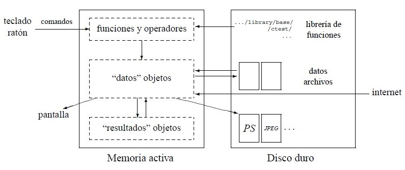

Back to Top

### Instalación de R, RStudio y paquetes

## Instalación de R

1. Ingresar a https://www.r-project.org/
2. Elegir el CRAN (Comprehensive R Archive Network)
3. Escoger versión del sistema operativo.
4. Instalar R por primera vez.

[figure not shown]

## R como una calculadora

```r
3*8
```

```
## [1] 24
```

```r
2.8/6.8
```

```
## [1] 0.4117647
```

```r
sqrt(25)
```

```
## [1] 5
```

Además, cada operación anterior puede ser almacenada en un “objeto”

```r
a<-3*8
b<-2.8/6.8
D<-sqrt(25)
```

## Instalación de RStudio

1. Ingresar a https://www.rstudio.com/
2. Productos
3. Escoger versión según el Sistema Operativo

[figure not shown]

## Instalación de paquetes

Además de las funciones básicas, R tiene un gran número de paquetes especializados.

Los paquetes se instalan una sola vez y deben ser cargados en cada inicio de sesión.

Se utiliza la siguiente función:

```
install.packages("dplyr",dependencies = TRUE)
```

Una vez instalado, debemos cargarlo con cualquiera de estos comandos:

```
require(dplyr)
library("dplyr")
```

Para instalar un paquete desde otro repositorio:

```
install.packages("survey", repos="http://r-forge.r-project.org", type="source")
library(survey)
```

Desde github y con otra forma de cargar una función de una librería:

```
install.packages("githubinstall")
githubinstall::githubinstall("twitter/AnomalyDetection")
```

Otra forma de cargar desde github:

```
source("https://install-github.me/r-lib/callr")
library("callr")
```

Para poder ver los paquetes instalados y disponibles podemos utilizar:

```
library()
installed.packages()
.packages(all.available=TRUE)
available.packages()
```

Para saber cuál fue el último paquete instalado utilizamos:

```
(.packages())
```

Es importante saber que funciones tiene cada paquete, para esto utilizamos:

```
ls("package:dplyr")
```

Back to Top

## Estructuras de Datos

Las estructuras de datos en R se organizan por: Dimensionalidad y Homogeneidad o heterogeneidad.

R no tiene estructuras 0d (tipo escalar). Los números y strings individuales son considerados como vectores de longitud 1.

```r
# no mostrar advertencias
options(warn = -1)
x <- 9
x
```

```
## [1] 9
```

El texto luego de # es un comentario (no es interpretado por R). Para crear un objeto se utiliza el operador de asignación <-, =, ->.

```r
y="SSh"
y
```

```
## [1] "SSh"
```

## Vectores

La estructura de datos básica de R son los vectores, estos se dividen en Vectores atómicos y listas.

## Propiedades:

Tipo: ¿Qué es?

```r
typeof(x)
```

```
## [1] "double"
```

Longitud: Número de elementos.

```r
length(x)
```

```
## [1] 1
```

Atributos: Características.

```r
attributes(x)
```

[output not shown]

## Vectores Atómicos

Los elementos de un vector atómico son del mismo tipo a diferencia de los elementos de una lista que pueden ser de diferente tipo. Los tipos comunes son:

- double (numeric)
- integer
- character
- logical

## Función combinar

Un vector es creado mediante la función c( ) (combinar).

```r
vec <- c(1, 2)
vec
```

```
## [1] 1 2
```

## Tipos de Vectores Atómicos:

Vector double;

```r
dbl_vec <- c(3.5, 2, -1)
```

Vector entero: Use el sufijo L para crear un vector entero;

```r
int_vec <- c(3L, 7L, 1L)
```

Vector caracter: Use “ ” para crear un vector caracter;

```r
chr_vec <- c("R",  "Users", "Group - Ecuador")
```

Vector lógico: Use TRUE y FALSE o T y F para crear un vector lógico.

```r
log_vec <- c(FALSE, TRUE, F, T)
```

Para determinar si un vector vec es atómico utilizamos is.atomic(vec).

```r
vec <- c(3.5, 2, -1)
is.atomic(vec)
```

```
## [1] TRUE
```

Para determinar el tipo de un vector vec utilizamos typeof(vec).

```r
vec <- c("R",  "Users", "Group - Ecuador")
typeof(vec)
```

```
## [1] "character"
```

Para verificar si un vector vec es de un tipo en específico, se utilizan las funciones “is”:

```r
is.character(vec)
```

```
## [1] TRUE
```

```r
is.double(vec)
```

```
## [1] FALSE
```

```r
is.integer(vec)
```

```
## [1] FALSE
```

```r
is.logical(vec)
```

```
## [1] FALSE
```

Elementos de un vector atómico: La componente i de vec se obtiene mediante vec[i].

Componente 5 de vec:

```r
vec <- c(6, 1, 3, 6, 10, 5)
vec[5]
```

```
## [1] 10
```

Para seleccionar varios elementos utilizamos vec[c(elementos)].

```r
# elementos 2 y 4
vec[c(2, 4)]
```

```
## [1] 1 6
```

Para omitir el elemento i de vec se utiliza vec[-i].

```r
vec <- c(6, 1, 3, 6, 10, 5)
vec[-5]
```

```
## [1] 6 1 3 6 5
```

Para omitir varios elementos utilizamos vec[-c(elementos)].

```r
# omitir los elementos 2 y 4
vec[-c(2, 4)]
```

```
## [1]  6  3 10  5
```

Generación de secuencias: El operador a:b genera el vector a, a+1, a+2, …, b.

```r
1:10
```

```
##  [1]  1  2  3  4  5  6  7  8  9 10
```

```r
5:-5
```

```
##  [1]  5  4  3  2  1  0 -1 -2 -3 -4 -5
```

La función seq( ) genera secuencias controlando: inicio, fin y salto.

```r
seq(from = 1, to = 10, by = 0.5)
```

```
##  [1]  1.0  1.5  2.0  2.5  3.0  3.5  4.0  4.5  5.0  5.5  6.0  6.5  7.0  7.5
## [15]  8.0  8.5  9.0  9.5 10.0
```

```r
seq(from = -4, to = 4, length = 5)
```

```
## [1] -4 -2  0  2  4
```

vec[c(TRUE, FALSE)] permite obtener determinados elementos:

```r
# elementos 2, 4, 6
vec <- c(6, 1, 3, 6, 10, 5)
vec[c(FALSE, TRUE, FALSE, TRUE, FALSE, TRUE)]
```

```
## [1] 1 6 5
```

Equivalente a:

```r
vec[c(2, 4, 6)]
```

```
## [1] 1 6 5
```

## Operaciones con vectores

A continuación, se resumen las operaciones básicas con vectores atómicos:

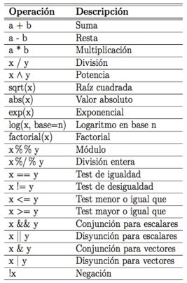

Función all(x) retorna TRUE si todas las componentes de x son TRUE.

```r
x <- c(TRUE, TRUE, TRUE)
all(x)
```

```
## [1] TRUE
```

```r
y <- c(TRUE, FALSE, TRUE)
all(y)
```

```
## [1] FALSE
```

Función any(x) retorna TRUE si al menos una componente de x es TRUE.

```r
x <- c(FALSE, FALSE, FALSE)
any(x)
```

```
## [1] FALSE
```

```r
y <- c(FALSE, TRUE, FALSE)
any(y)
```

```
## [1] TRUE
```

Negación !x cambia las componentes de x de: TRUE a FALSE y de FALSE a TRUE:

```r
x <- c(TRUE, FALSE, TRUE)
!x
```

```
## [1] FALSE  TRUE FALSE
```

Conjunción x & y retorna TRUE solo si las componentes de x & y son TRUE:

```r
x <- c(TRUE, TRUE, FALSE)
y <- c(FALSE, TRUE, TRUE)
x & y
```

```
## [1] FALSE  TRUE FALSE
```

```r
x && y # conjuncion para escalares
```

```
## [1] FALSE
```

Disyunción x | y retorna TRUE si al menos una componente de x o y es TRUE

```r
x <- c(TRUE, TRUE, FALSE)
y <- c(FALSE, TRUE, TRUE)
x | y
```

```
## [1] TRUE TRUE TRUE
```

```r
x || y # disyuncion para escalares
```

```
## [1] TRUE
```

Dado un vector lógico x:

```r
x <- c(TRUE, TRUE, FALSE, TRUE, FALSE)
```

sum(x). Cuenta el número de TRUE en x.

```r
sum(x)
```

```
## [1] 3
```

mean(x). Muestra el porcentaje de TRUE en x.

```r
mean(x)
```

```
## [1] 0.6
```

```r
sum(x)/length(x)
```

```
## [1] 0.6
```

Test de igualdad y desigualdad

```r
x <- c(3, 5, 2, 3, 1)
x==3
```

```
## [1]  TRUE FALSE FALSE  TRUE FALSE
```

```r
y <- x==3 # componentes iguales a 3
z <- x!=3 # componentes distintas a 3
data.frame(x, y, z)
```

```
##   x     y     z
## 1 3  TRUE FALSE
## 2 5 FALSE  TRUE
## 3 2 FALSE  TRUE
## 4 3  TRUE FALSE
## 5 1 FALSE  TRUE
```

```r
x[x!=3] # componentes de x distintas a 3
```

```
## [1] 5 2 1
```

Coerción: Si combinamos tipos diferentes, serán coercionados al tipo más ﬂexible dado por la jerarquía:

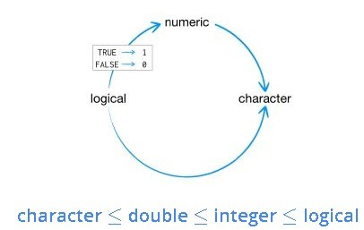

Para coercionar un vector x a un determinado tipo, se utilizan las funciones “as”

```r
as.character(x)
```

```
## [1] "3" "5" "2" "3" "1"
```

```r
as.double(x)
```

```
## [1] 3 5 2 3 1
```

```r
as.integer(x)
```

```
## [1] 3 5 2 3 1
```

```r
as.logical(x)
```

```
## [1] TRUE TRUE TRUE TRUE TRUE
```

```r
as.numeric(x)
```

```
## [1] 3 5 2 3 1
```